# Kapittel 5: En praktisk anvendelse av $\nabla$-operatoren i meteorologi

## 5.1 Innledning

Her skal vi prøve å reprodusere noen av eksemplene fra kapittel 5 i boken. Vi bruker et litt annet datasett enn det som gjøres i boken. Les gjerne innledningen i kapittel 5 i boken før du begynner.

## 5.2 Innlesing av data

Her laster vi ned datasettet fra nettet (det er 18GB, så det kan ta litt tid).

```julia
using Downloads
url = "https://thredds.met.no/thredds/fileServer/nora3_subset_atmos/atm_hourly/arome3km_1hr_200202.nc"
dl_path = joinpath(homedir(), "Downloads", "arome3km_1hr_200202.nc")
```

```
"/home/kristian/Downloads/arome3km_1hr_200202.nc"
```

```julia
Downloads.download(url, dl_path) # dette kan ta lang tid, filen er 18GB!
```

Vi leser inn datasettet med `NCDatasets.jl`.

```julia
using NCDatasets
ds = NCDataset(dl_path);
```

Så må vi prosessere dataene. Vi finner akkurat det tidspunktet vi vil ha, og henter ut de dataene vi trenger. Datasettet gjelder et stort område, så vi filtrerer ut omtrent halvparten av dataene.

```julia
using Dates
datetime = DateTime(2002, 2, 19, 18) # 19. Februar 2002 18:00
time_ix = findfirst(ds["time"] .== datetime) # indeks for tiden 19. Februar 2002 18:00

# filterer ut halvparten av dataene
ny_full = length(ds["latitude"][1, :])
ny_sub = ny_full ÷ 2

p = Array(ds["air_pressure_at_sea_level"][:, 1:ny_sub, 1, time_ix] ./ 100 .|> Float32)
wind_direction_from_degree = ds["wind_direction"][:, 1:ny_sub, 1, time_ix] .|> Float32
wind_direction_to_rad = deg2rad.(wind_direction_from_degree)
wind_speed = ds["wind_speed"][:, 1:ny_sub, 1, time_ix] .|> Float32
u = -wind_speed .* sin.(wind_direction_to_rad)
v = -wind_speed .* cos.(wind_direction_to_rad)
longitudes = Array(ds["longitude"][:, 1:ny_sub]) .|> Float32
latitudes = Array(ds["latitude"][:, 1:ny_sub]) .|> Float32
xs = Array(ds["x"]) .|> Float32
ys = Array(ds["y"])[1:ny_sub] .|> Float32
@show length(xs)
@show length(ys)
```

```
length(xs) = 889
length(ys) = 744
```

```
744
```

Her ser vi at vi har $889 \times 744$ punkter i datasettet.

Nå vil $p, u$ og $v$ være matriser der hvert element enten er en trykkverdi eller en komponent av vindstyrken. $p_{ij}$ er altså en diskret representasjon av skalarfeltet $p(x, y)$ som beskriver trykkfeltet i området, og $u_{ij}$ og $v_{ij}$ er diskrete representasjoner for komponentene av vindvektoren $\mathbf v = u(x, y)\mathbf i + v(x, y)\mathbf j$.

Vi kontrollerer størrelsene på matrisene:

```julia
@show size(p)
@show size(u)
@show size(v)
```

```
size(p) = (889, 744)
size(u) = (889, 744)
size(v) = (889, 744)
```

```
(889, 744)
```

Alle har $889$ punkter i øst/vest-retningen, og $744$ punkter i nord/sør-retningen.

Nå kan vi plotte en ramme rundt området vi skal jobbe med, slik som i boken. For å gjøre det, bruker vi pakken `GeoMakie.jl`. I motsetning til i boka, bruker vi ikke kartesiske koordinater, men vi bruker breddegrader og lengdegrader. I koden over er `longitudes` og `latitudes` matriser som beskriver lengdegradene og breddegradene til hvert punkt i datasettet.

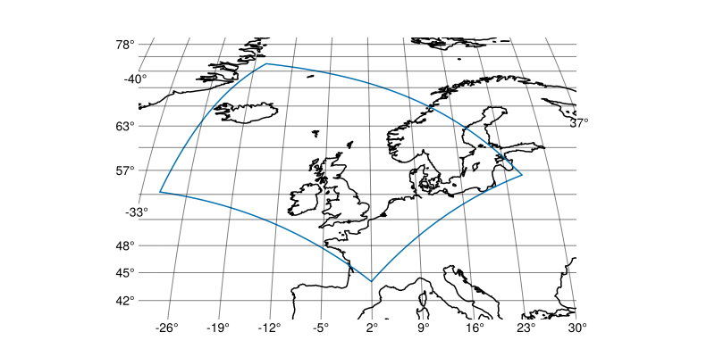

Figur 2.1: Værdata som vi skal behandle er innenfor det innrammede området på kartet.

```julia
using CairoMakie
using GeoMakie
limits = ((-22, 7), (52, 67))
bottom_points = Point2f.(Array(longitudes[:, 1]), Array(latitudes[:, 1]))
right_points = Point2f.(Array(longitudes[end, :]), Array(latitudes[end, :]))
top_points = Point2f.(Array(longitudes[:, end]), Array(latitudes[:, end]))
left_points = Point2f.(Array(longitudes[1, :]), Array(latitudes[1, :]))
points = vcat(bottom_points, right_points, reverse(top_points), reverse(left_points))

fig = Figure(size=(800, 400))
ax = GeoAxis(fig[1, 1]; limits = ((-30, 30), (40, 80)))
lines!(ax, GeoMakie.coastlines(50), color=:black)
lines!(ax, points)
fig
```

## 5.3 Plotting av isobarer

Vi kan nå plotte konturlinjer til trykket (isobarer). For å finne et riktig antall konturlinjer med passende trykkverdier kreves det gjerne litt eksperimentering. For dette feltet passer det bra med jevnt fordelte isobarer fra $980$ hPa til $1025$ hPa med $5$ hPa differanse. Husk at trykket er gitt som en matrise `p`.

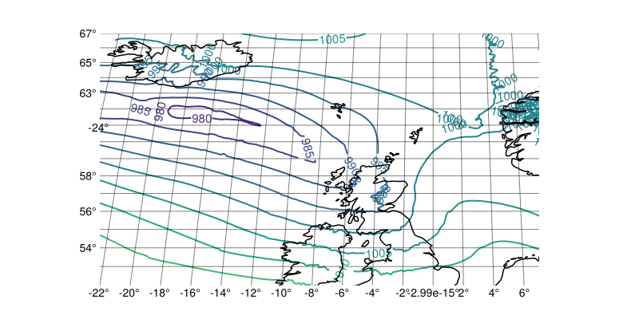

Isobarene $p = 980, 985, \dots, 1025$ hPa. Trykkfeltet viser et langstrakt lavtrykkområde som ligger mellom Skottland og Island, i likhet med det vi så i boka.

```julia
isobarer = 980:5:1025
fig = Figure(size=(800, 400))
ax = GeoAxis(fig[1, 1]; limits)
contour!(ax, longitudes, latitudes, p, levels=isobarer,
    labels=true, linewidth=2, labelsize=15
)
lines!(ax, GeoMakie.coastlines(50), color=:black)
fig
```

Vi kan også plotte trykkfeltet med innfylling av flatene mellom konturlinjene med `contourf!`.

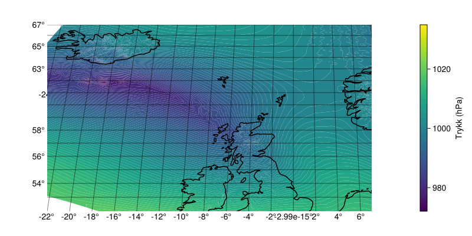

```julia
fig = Figure(size=(800, 400))
ax = GeoAxis(fig[1, 1]; limits)
cf = contourf!(ax, longitudes, latitudes, p, colormap=:viridis, levels=100)
lines!(ax, GeoMakie.coastlines(50), color=:black)
Colorbar(fig[1, 2], cf, label="Trykk (hPa)")
fig
```

## 5.4 Plotting av vindfelt

Siden vi nå har vindkomponentene gitt som to like store matriser kan vi enkelt plotte vindfeltet. Her passer vi på å ikke bruke alle punktene, da det ville gitt veldig mange piler. Vi bruker her en steglengde på $20$ punkter i hver retning. Vi plotter også trykkfeltet.

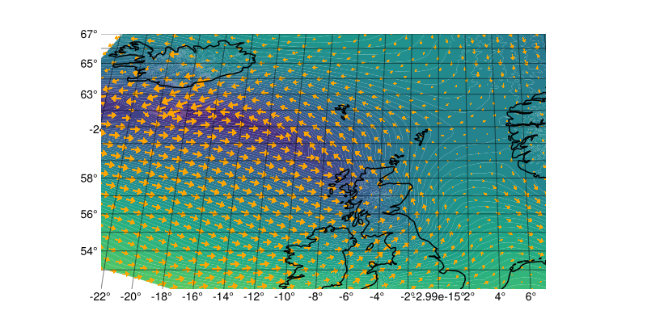

Figur 2.2: Vindfeltet visualisert som piler som viser vindretning og -styrke.

```julia
steg = 20
fig = Figure(size=(800, 400))
ax = GeoAxis(fig[1, 1]; limits)
contourf!(ax, longitudes, latitudes, p, levels = 100, colormap = :viridis)
arrows2d!(ax,
    longitudes[1:steg:end, 1:steg:end],
    latitudes[1:steg:end, 1:steg:end],
    u[1:steg:end, 1:steg:end],
    v[1:steg:end, 1:steg:end],
    lengthscale=0.03, color=:orange
)
lines!(ax, GeoMakie.coastlines(50), color=:black)
fig
```

Vi kan også plotte konturlinjer for vindstyrken, med innfylling av flatene mellom konturlinjene.

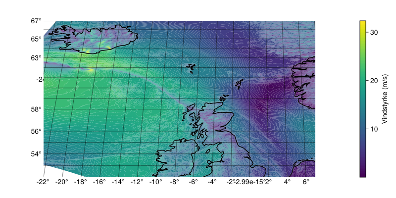

Figur 2.3: Konturlinjer for vindstyrke, med innfylling av flatene mellom konturlinjene.

```julia
fig = Figure(size = (800, 400))
ax = GeoAxis(fig[1, 1]; limits)
cf = contourf!(ax, longitudes, latitudes, wind_speed, colormap = :viridis, levels = 100)
lines!(ax, GeoMakie.coastlines(50), color = :black)
Colorbar(fig[1, 2], cf, label = "Vindstyrke (m/s)")
fig
```

Her ser vi mye kult! Her kan vi merke oss at vindstyrke-dataene gjelder i en høyde av $10$ meter over bakken:

```julia
display(ds["wind_speed"])
display(ds["height4"])
display(ds["height4"][1])
```

```
wind_speed (889 × 1489 × 1 × 672)
  Datatype:    Union{Missing, Float32} (Float32)
  Dimensions:  x × y × height4 × time
  Attributes:
   _FillValue           = 9.96921e36
   long_name            = Wind direction
   standard_name        = wind_speed
   units                = m/s
   grid_mapping         = projection_lambert
   coordinates          = longitude latitude
```

```
height4 (1)
  Datatype:    Float32 (Float32)
  Dimensions:  height4
  Attributes:
   description          = height above ground
   long_name            = height
   positive             = up
   units                = m
```

```
10.0f0
```

## 5.5 Divergens

Divergensen til et vektorfelt er en skalar størrelse. Denne størrelsen kan vi beregne i Julia dersom vi kjenner komponentene til vektorfeltet. Vindfeltet har komponenter $u$ og $v$, og uttrykket for divergensen er
$$\nabla \cdot \mathbf v = \frac{\partial u}{\partial x} + \frac{\partial v}{\partial y}$$

Her hvor $u$ og $v$ er kjent bare i gitterpunktene ved matrisene $u_{ij}$ og $v_{ij}$, er de deriverte i uttrykket for divergensen approksimert med
$$\frac{\partial u}{\partial x} \approx \frac{u_{i+1,j} - u_{i-1,j}}{\Delta x}, \text{ og }\\
\frac{\partial v}{\partial y} \approx \frac{v_{i,j+1} - v_{i,j-1}}{\Delta y}$$

Her lager vi en funksjon for å beregne divergensen numerisk. Når vi er på randen av området bruker vi ensidige differanser, mens vi i indre punkter bruker sentrale differanser som i ligningen over.

```julia
"""
    punkt_divergens(u, v, i, j, Δx, Δy)
Beregner divergensen i punktet med indeks (i, j) med ensidige og sentrale differanser.

Argumenter:
- u: Matrise med u-komponenten av vinden
- v: Matrise med v-komponenten av vinden
- i: Indeks i x-retningen
- j: Indeks i y-retningen
- Δx: Steglengde i x-retningen
- Δy: Steglengde i y-retningen

Returnerer:
Divergensen i punktet (i, j)
"""
function punkt_divergens(u, v, i, j, Δx, Δy)
    if i == 1
        dudx = (u[i + 1, j] - u[i, j]) / Δx
    elseif i == size(u, 1)
        dudx = (u[i, j] - u[i - 1, j]) / Δx
    else
        dudx = (u[i + 1, j] - u[i - 1, j]) / (2 * Δx)
    end
    if j == 1
        dvdy = (v[i, j + 1] - v[i, j]) / Δy
    elseif j == size(v, 2)
        dvdy = (v[i, j] - v[i, j - 1]) / Δy
    else
        dvdy = (v[i, j + 1] - v[i, j - 1]) / (2 * Δy)
    end
    return dudx + dvdy
end

"""
    divergens(u, v, Δx, Δy)
Beregner divergensen av vinden med ensidige og sentrale differanser.

Argumenter:
- u: Matrise med u-komponenten av vinden
- v: Matrise med v-komponenten av vinden
- Δx: Steglengde i x-retningen
- Δy: Steglengde i y-retningen

Returnerer:
- div: Matrise med divergensen av vinden
"""
function divergens(u, v, Δx, Δy)
    div = similar(u)
    I = 1:size(u, 1)
    J = 1:size(u, 2)
    for i in I, j in J
        div[i, j] = punkt_divergens(u, v, i, j, Δx, Δy)
    end
    return div
end
```

Nå kan vi beregne divergensen til hastighetsfeltet.

```julia
Δx = xs[2] - xs[1]
Δy = ys[2] - ys[1]
wind_div = divergens(u, v, Δx, Δy)
```

```
889×744 Matrix{Float32}:
 1.83983f-5  2.01959f-5   1.77497f-5  …   6.46355f-6    5.46859f-6
 2.43273f-5  2.43386f-5   2.01931f-5      4.39634f-6    5.58828f-6
 2.47338f-5  1.90388f-5   1.6778f-5       7.30273f-6    9.18604f-6
 2.51377f-5  2.07828f-5   1.4629f-5       3.0613f-6    -2.67876f-6
 1.75943f-5  1.41999f-5   1.52153f-5      2.00943f-6    6.17037f-7
 2.13197f-5  1.17784f-5   1.04639f-5  …   7.54949f-6    7.96339f-6
 1.60731f-5  1.51459f-5   4.90117f-6      3.89254f-5    4.30663f-5
 8.11919f-6  1.11851f-5   9.13143f-7      5.29115f-5    5.93644f-5
 1.0517f-5   1.14041f-5   1.89376f-6      2.8094f-5     2.60035f-5
 1.50641f-5  7.31389f-6   1.61179f-6      1.12643f-5    1.63356f-5
 ⋮                                    ⋱
 7.85493f-6  1.7078f-5    1.75644f-5  …  -0.000187383  -0.000123478
 4.70862f-6  7.14492f-6   1.56761f-5     -9.13961f-5    5.74478f-6
 1.36192f-5  8.53079f-7  -1.53676f-5     -7.85856f-5   -3.08362f-5
 1.50566f-5  8.07851f-6  -6.70437f-6      2.15464f-5    5.16415f-5
 1.62689f-5  1.35937f-5   1.01873f-5      1.66683f-5    9.27645f-6
 1.01798f-5  1.27396f-5   9.91087f-6  …  -1.5585f-6    -1.62287f-5
 4.72426f-6  5.37005f-6   3.71983f-6      9.872f-6      1.09482f-5
 1.08974f-5  7.73772f-6   4.28807f-6      5.4751f-6    -1.35802f-5
 1.47243f-5  1.45188f-5   6.58732f-6     -9.2442f-6     9.93192f-6
```

Vi kan nå plotte divergensen:

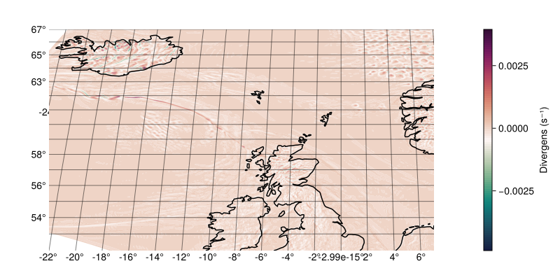

Figur 2.4: Divergensen til vindfeltet.

```julia
fig = Figure(size = (800, 400))
ax = GeoAxis(fig[1, 1]; limits)
cf = contourf!(ax, longitudes, latitudes, wind_div, colormap = :curl, levels = 100)
lines!(ax, GeoMakie.coastlines(50), color = :black)
Colorbar(fig[1, 2], cf, label = "Divergens (s⁻¹)")
fig
```

## 5.6 Virvling

Virvlingen for vindfeltet er rettet normalt på $xy$-planet og størrelsen er
$$c = \frac{\partial v}{\partial x} - \frac{\partial u}{\partial y}.
\tag{2.1}$$

På tilsvarende måte som divergensen approksimeres de deriverte med differanser av de diskrete verdiene:

$$\frac{\partial v}{\partial x} \approx \frac{v_{i+1,j} - v_{i-1,j}}{\Delta x}, \text{ og }\\
\frac{\partial u}{\partial y} \approx \frac{u_{i,j+1} - u_{i,j-1}}{\Delta y}
\tag{2.2}$$

Her definerer vi en funksjon for å beregne virvlingen numerisk:

```julia
"""
    punkt_virvling(u, v, i, j, Δx, Δy)
Beregner virvlingen i punktet med indeks (i, j) med ensidige og sentrale differanser.

Argumenter:
- u: Matrise med u-komponenten av vinden
- v: Matrise med v-komponenten av vinden
- i: Indeks i x-retningen
- j: Indeks i y-retningen
- Δx: Steglengde i x-retningen
- Δy: Steglengde i y-retningen

Returnerer:
- virvlingen i punktet (i, j)
"""
function punkt_virvling(u, v, i, j, Δx, Δy)
    if i == 1
        dvdx = (v[i + 1, j] - v[i, j]) / Δx
    elseif i == size(u, 1)
        dvdx = (v[i, j] - v[i - 1, j]) / Δx
    else
        dvdx = (v[i + 1, j] - v[i - 1, j]) / (2 * Δx)
    end
    if j == 1
        dudy = (u[i, j + 1] - u[i, j]) / Δy
    elseif j == size(v, 2)
        dudy = (u[i, j] - u[i, j - 1]) / Δy
    else
        dudy = (u[i, j + 1] - u[i, j - 1]) / (2 * Δy)
    end
    return dvdx - dudy
end

"""
    virvling(u, v, Δx, Δy)
Beregner virvlingen av vinden med ensidige og sentrale differanser.

Argumenter:
- u: Matrise med u-komponenten av vinden
- v: Matrise med v-komponenten av vinden
- Δx: Steglengde i x-retningen
- Δy: Steglengde i y-retningen

Returnerer:
- virvling: Matrise med virvlingen av vinden
"""
function virvling(u, v, Δx, Δy)
    virvling = similar(u)
    I = 1:size(u, 1)
    J = 1:size(u, 2)
    for i in I, j in J
        virvling[i, j] = punkt_virvling(u, v, i, j, Δx, Δy)
    end
    return virvling
end
```

Nå kan vi beregne virvlingen til hastighetsfeltet.

```julia
wind_curl = virvling(u, v, Δx, Δy)
```

```
889×744 Matrix{Float32}:
 -4.7064f-5   -4.00103f-5  -3.73169f-5  …  -3.20467f-5   -3.44504f-5
 -4.36382f-5  -3.83372f-5  -4.12759f-5     -2.84282f-5   -3.00125f-5
 -4.26932f-5  -3.87092f-5  -3.94645f-5     -2.80668f-5   -3.26777f-5
 -3.99119f-5  -3.97975f-5  -3.71017f-5     -2.64653f-5   -2.86091f-5
 -4.19907f-5  -3.91131f-5  -3.63212f-5     -3.13197f-5   -2.68424f-5
 -3.27127f-5  -3.47284f-5  -3.81683f-5  …  -4.09121f-5   -3.69409f-5
 -3.193f-5    -3.98464f-5  -3.48578f-5     -5.95521f-5   -5.4457f-5
 -3.63052f-5  -3.84787f-5  -3.22351f-5     -7.35736f-5   -7.71211f-5
 -3.99177f-5  -3.55319f-5  -3.66838f-5     -4.92478f-5   -4.91211f-5
 -4.01982f-5  -3.49329f-5  -3.3492f-5      -3.07044f-5   -3.00481f-5
  ⋮                                     ⋱
 -1.72636f-5  -2.76212f-5  -3.05795f-5  …  -0.000172363  -5.36797f-5
 -2.50453f-5  -2.86128f-5  -3.96322f-5     -0.000298058  -0.000256035
 -1.99852f-5  -2.25475f-5  -2.30584f-5     -0.000286015  -0.00032936
 -1.07731f-5  -2.18833f-5  -2.00353f-5     -0.000157204  -0.000189765
 -1.06738f-5  -2.20131f-5  -1.76108f-5     -8.76191f-5   -0.000128811
 -1.02326f-5  -1.73569f-5  -1.35183f-5  …  -7.55898f-5   -7.79094f-5
 -1.01861f-5  -1.13351f-5  -1.87071f-5     -2.13147f-5   -3.10573f-5
 -1.88166f-6  -4.15877f-6  -1.38658f-5     -4.13696f-7   -3.36957f-6
 -3.47157f-6  -1.9466f-6   -4.45137f-6     -1.532f-5     -2.35832f-6
```

Vi kan nå plotte konturlinjer for virvlingen. Her velger vi å zoome inn på et mindre område sør for Island.

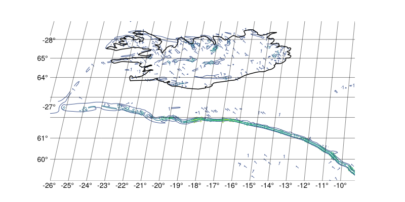

Figur 2.5: Konturlinjer for virvlingen til vindfeltet, skalert med $\Delta x$.

```julia
fig = Figure(size = (800, 400))
ax = GeoAxis(fig[1, 1]; limits = ((-26, -10), (59, 67)))
c = contour!(ax, longitudes, latitudes, wind_curl * Δx, levels = [1, 5, 10, 15, 20], labels = true)
lines!(ax, GeoMakie.coastlines(50), color = :black)
# Colorbar(fig[1, 2], c, label = "Virvling (s⁻¹)")
fig
```

Vi tar også med et plot med innfylling av flatene mellom konturlinjene, for å få frem flere detaljer:

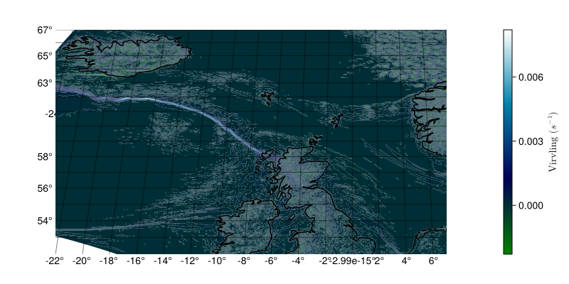

```julia
fig = Figure(size = (800, 400))
ax = GeoAxis(fig[1, 1]; limits)
cf = contourf!(ax, longitudes, latitudes, wind_curl, colormap = :ocean, levels = 100)
lines!(ax, GeoMakie.coastlines(50), color = :black)
Colorbar(fig[1, 2], cf, label = L"Virvling ($s^{-1}$)")
fig
```

## 5.7 Tolkninger

Her refererer vi til kapittel 5.7 i boken, som gjelder uavhengig av programmeringsspråk.